# NOBEL WINNERS

Sara ZOUIRCHI

21/06/2020

## Le prix Nobel est une récompense de portée internationale. Remis pour la première fois en 1901, les prix sont décernés chaque année à des personnes « ayant apporté le plus grand bénéfice à l’humanité », par leurs inventions, découvertes et améliorations dans différents domaines de la connaissance, par l’œuvre littéraire la plus impressionnante, ou par leur travail en faveur de la paix, suivant ainsi les derniers vœux d’Alfred Nobel, inventeur de la dynamite.

```r
nobel <- read_csv("https://raw.githubusercontent.com/rfordatascience/tidytuesday/master/data/2019/2019-05-14/nobel_winners.csv")
nobel_winners <- readr::read_csv("https://raw.githubusercontent.com/rfordatascience/tidytuesday/master/data/2019/2019-05-14/nobel_winners.csv") %>%
  mutate_all(., tolower) %>%
  mutate(prize_year = as.integer(prize_year)) %>%
  mutate(birth_country = ifelse(grepl('\\(', birth_country), str_extract(birth_country, "(?<=\\().*?(?=\\))"), birth_country),
         death_country = ifelse(grepl('\\(', death_country), str_extract(death_country, "(?<=\\().*?(?=\\))"), death_country)) %>%
  mutate(birth_country = case_when(birth_country == "scotland" ~ "united kingdom",
                                   birth_country == "northern ireland" ~ "united kingdom",
                                   grepl("czech", birth_country) ~ "czechia",
                                   birth_country == "east_germany" ~ "germany",
                                   TRUE ~ birth_country),
         death_country = case_when(death_country == "scotland" ~ "united kingdom",
                                   death_country == "northern ireland" ~ "united kingdom",
                                   grepl("czech", death_country) ~ "czechia",
                                   death_country == "east_germany" ~ "germany",
                                   TRUE ~ death_country)) %>%
  select(prize_year, category, birth_date, birth_country, gender, organization_name, organization_country, death_country)
nobel_winners <- readr::read_csv("https://raw.githubusercontent.com/rfordatascience/tidytuesday/master/data/2019/2019-05-14/nobel_winners.csv") %>%
  distinct(full_name, prize_year, category, .keep_all = TRUE) %>%
  mutate(decade = 10 * (prize_year %/% 10),
         age = prize_year - year(birth_date))
nobel_winner_all_pubs <- readr::read_csv("https://raw.githubusercontent.com/rfordatascience/tidytuesday/master/data/2019/2019-05-14/nobel_winner_all_pubs.csv") %>%
  mutate(prize_decade = 10 * (prize_year %/% 10))
```

## Les gagnants par an en dernière décennie (par catégorie)

## Commentaire: Il y a presque un gagnant chaque année en littérature, en médecine le nombre de gagnat par an a augmenté, en physique aussi pour l’économie, elle était introduite à partir des années 60 par un peu près de 1 gagnant au bout de deux ans et puis 2 gagnant plutard.

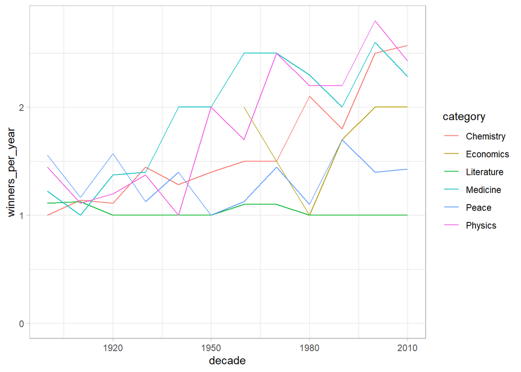

```r
nobel_winners %>%
  group_by(category, decade) %>%
  summarize(winners = n(),
            winners_per_year = winners / n_distinct(prize_year)) %>%
  ggplot(aes(decade, winners_per_year, color = category)) +
  geom_line() +
  expand_limits(y = 0)
```

## Nom complet des gagnats par catégorie (nombre de prix)

## Commentaire: Trois prix en catégorie “paix” par la comité international de la Croix rouge. Deux prix en chimie par Frederick Sanger. Deux prix en physique par John Bardeen et ainsi de suite.

```r
nobel_winners %>%
  distinct(full_name, prize_year, category) %>%
  group_by(full_name) %>%
  mutate(prizes = n(),
         distinct_prizes = n_distinct(category)) %>%
  arrange(desc(prizes), full_name)
```

```
## # A tibble: 911 x 5
## # Groups:   full_name [904]
##    prize_year category  full_name                         prizes distinct_prizes
##         <dbl> <chr>     <chr>                              <int>           <int>
##  1       1917 Peace     Comité international de la Croix~      3               1
##  2       1944 Peace     Comité international de la Croix~      3               1
##  3       1963 Peace     Comité international de la Croix~      3               1
##  4       1958 Chemistry Frederick Sanger                       2               1
##  5       1980 Chemistry Frederick Sanger                       2               1
##  6       1956 Physics   John Bardeen                           2               1
##  7       1972 Physics   John Bardeen                           2               1
##  8       1954 Chemistry Linus Carl Pauling                     2               2
##  9       1962 Peace     Linus Carl Pauling                     2               2
## 10       1903 Physics   Marie Curie, née Sklodowska            2               2
## # ... with 901 more rows
```

## Répartition des gagants du prix Nobel par sexe au fil du temps.

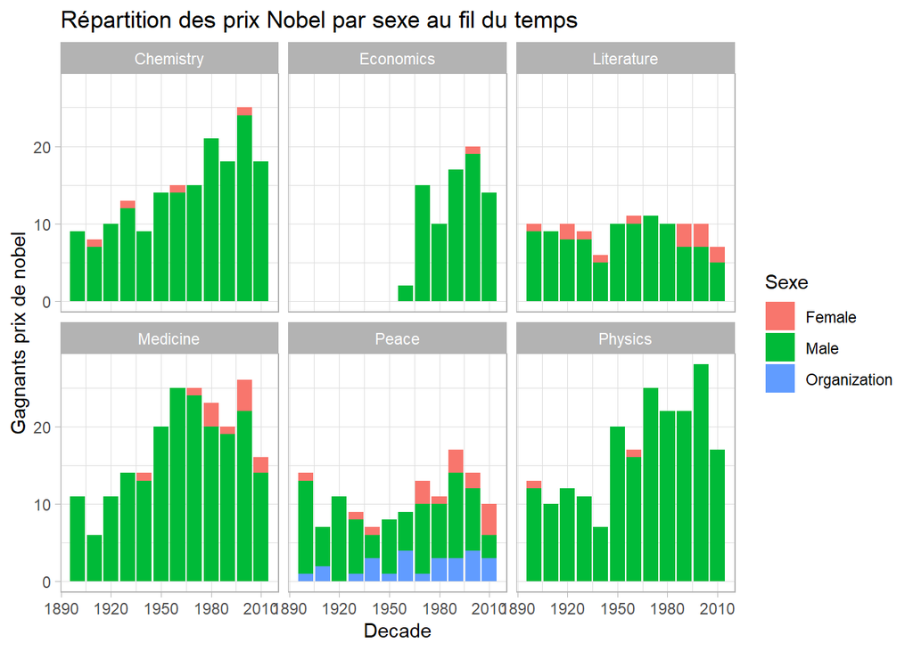

```r
nobel_winners %>%
  count(decade,
        category,
        gender = coalesce(gender, laureate_type)) %>%
  group_by(decade, category) %>%
  mutate(percent = n / sum(n)) %>%
  ggplot(aes(decade, n, fill = gender)) +
  geom_col() +
  facet_wrap(~ category) +
  labs(x = "Decade",
       y = "Gagnants prix de nobel",
       fill = "Sexe",
       title = "Répartition des prix Nobel par sexe au fil du temps")
```

## D’après les graphiques obtenus, on a remarqué que le nombre des femmes gagnantes et inférieur aux hommes gagnants. D’où la représentation suivante, pour voir le nombre des femmes gagnantes des prix Nobel par catégorie

```r
nobel %>%
  filter(gender == "Female") %>%
  select(full_name, prize_year, category) %>%
  group_by(category) %>%
  count() %>%
  arrange(desc(n))
```

```
## # A tibble: 6 x 2
## # Groups:   category [6]
##   category       n
##   <chr>      <int>
## 1 Peace         16
## 2 Literature    14
## 3 Medicine      12
## 4 Chemistry      4
## 5 Economics      2
## 6 Physics        2
```

## creuser un peu plus, j’ai affiché les noms complets des gagnantes, la date d’obtention du prix et la catégorie.

```r
nobel %>%
  filter(gender == "Female") %>%
  select(full_name, prize_year, category) %>% head()
```

```
## # A tibble: 6 x 3
##   full_name                                                 prize_year category
##   <chr>                                                          <dbl> <chr>
## 1 Marie Curie, née Sklodowska                                     1903 Physics
## 2 Baroness Bertha Sophie Felicita von Suttner, née Countes~       1905 Peace
## 3 Selma Ottilia Lovisa Lagerlöf                                   1909 Literatu~
## 4 Marie Curie, née Sklodowska                                     1911 Chemistry
## 5 Grazia Deledda                                                  1926 Literatu~
## 6 Sigrid Undset                                                   1928 Literatu~
```

## Il y avait 26 organisations plutôt que des individus qui ont remporté le prix Nobel de la paix.

```r
nobel %>% filter(is.na(gender)) %>% select(full_name, category)
```

```
## # A tibble: 26 x 2
##    full_name                                                            category
##    <chr>                                                                <chr>
##  1 Institut de droit international (Institute of International Law)     Peace
##  2 Bureau international permanent de la Paix (Permanent International ~ Peace
##  3 Comité international de la Croix Rouge (International Committee of ~ Peace
##  4 Office international Nansen pour les Réfugiés (Nansen International~ Peace
##  5 Comité international de la Croix Rouge (International Committee of ~ Peace
##  6 Friends Service Council (The Quakers)                                Peace
##  7 American Friends Service Committee (The Quakers)                     Peace
##  8 Office of the United Nations High Commissioner for Refugees (UNHCR)  Peace
##  9 Comité international de la Croix Rouge (International Committee of ~ Peace
## 10 Ligue des Sociétés de la Croix-Rouge (League of Red Cross Societies) Peace
## # ... with 16 more rows
```

## Répartition des gagnants du prix Nobel par âge

## Commentaire: Cette représentation permet de voir l’âge des gagnant.

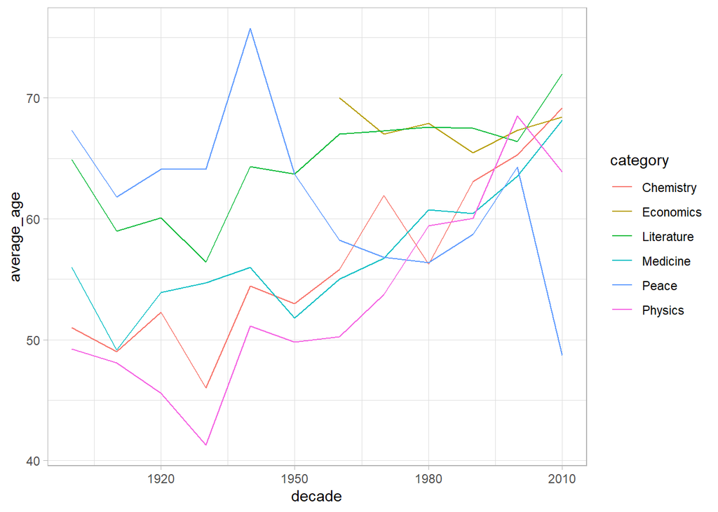

```r
nobel_winners %>%
  filter(!is.na(age)) %>%
  group_by(decade, category) %>%
  summarize(average_age = mean(age),
            median_age = median(age)) %>%
  ggplot(aes(decade, average_age, color = category)) +
  geom_line()
```

##Représentation des gagnants par pays de naissance.

## Commentaire: Pour chaque catégorie,on essaye d’étudier le pays de naissance des gagants,pour la physique et la médicine on remarque que c’est plus élevé au Etats-UNI, pour la littérature est un peu international, la paix également est international.

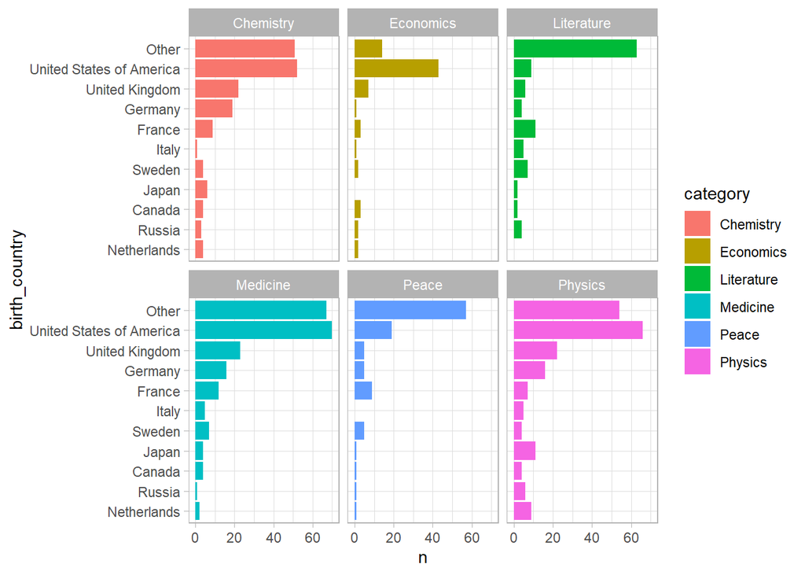

```r
nobel_winners %>%
  filter(!is.na(birth_country)) %>%
  count(birth_country = fct_lump(birth_country, 9),
        category,
        sort = TRUE) %>%
  mutate(birth_country = fct_reorder(birth_country, n)) %>%
  ggplot(aes(birth_country, n, fill = category)) +
  geom_col() +
  facet_wrap(~ category) +
  coord_flip()
```

```r
map.world <- map_data('world')
map_countries <- distinct(map.world, region)
```

## Filtrer le jeu de données d’origine pour n’inclure que les pays de naissance qui ont plus de 5 gagnants et qui ne manquent pas. Cela réduit notre ensemble de données de 969 à 792 gagnants et 24 principaux pays.

```r
nobel_countries <- nobel %>% group_by(birth_country) %>% count() %>% filter(n >5, !is.na(birth_country)) %>% arrange(desc(n))
anti_join(nobel_countries, map.world, by = c('birth_country' = 'region')) %>% select(birth_country) %>% group_by(birth_country) %>% count(sort = T)
```

```
## # A tibble: 6 x 2
## # Groups:   birth_country [6]
##   birth_country                n
##   <chr>                    <int>
## 1 Germany (Poland)             1
## 2 Prussia (Germany)            1
## 3 Prussia (Poland)             1
## 4 Scotland                     1
## 5 United Kingdom               1
## 6 United States of America     1
```

## Et corrigeons ces décalages en les recodant sous les noms qui se trouvent dans notre jeu de données map.world.

```r
nobel <- nobel %>% mutate(birth_country = recode(birth_country,
                                                 "United States of America" = "USA",
                                                 "United Kingdom" = "UK",
                                                 "Scotland" = "UK",
                                                 "Northern Ireland" = "Ireland",
                                                 "Germany (Poland)" = "Poland",
                                                 "Prussia (Germany)" = "Germany",
                                                 "Prussia (Poland)" = "Poland"))
```

```r
country_list <- nobel_countries$birth_country
nobel_small <- nobel %>% filter(birth_country %in% country_list)
```

## Combinant le jeu de données nobel et le jeu de données de carte.

```r
nobel_small <- left_join(nobel_small, nobel_countries, by ="birth_country") %>% rename("num_winners" = "n") #this add the count of winners
nobel_map <- left_join( map.world, nobel_small, by = c("region"= "birth_country"))
```

[figure not shown]

```r
ggplot(nobel_map, aes( x = long, y = lat, group = group)) +
  geom_polygon(aes(fill = num_winners))+
  scale_fill_gradientn(colours = c('#461863','#404E88','#2A8A8C','#7FD157','#F9E53F')
                       ,values = scales::rescale(c(5, 50, 100, 200, 300))
                       ,labels = comma
                       ,breaks = c(5, 50, 100, 200, 300)
  ) +
  labs(fill = '# of Nobel Winners'
              ,title = 'U.S and europe win most nobel prizes'
       ,x = NULL
       ,y = NULL) +
  theme(text = element_text(family = 'Gill Sans', color = '#EEEEEE')
        ,plot.title = element_text(size = 20)
        ,plot.subtitle = element_text(size = 14)
        ,axis.ticks = element_blank()
        ,axis.text = element_blank()
        ,panel.grid = element_blank()
        ,panel.background = element_rect(fill = '#333333')
        ,plot.background = element_rect(fill = '#333333')
        ,legend.position = c(.18,.36)
        ,legend.background = element_blank()
        ,legend.key = element_blank()
  ) +
  annotate(geom = 'text'
           ,label = 'Source: Kaggle |Plot by @sarazouirchi'
           ,x = 18, y = -55
           ,size = 3
           ,family = 'Gill Sans'
           ,color = '#CCCCCC'
           ,hjust = 'left')
```